# AnushaVivekanand_EDA_Capstone

Anusha_Vivekanand

2024-02-17

```r
options(repos = c(CRAN = "https://cloud.r-project.org/"))
install.packages("GGally")
```

# 1 Introduction

> Unbanked individuals constitute an underserved demographic and a largely untapped market for reputable creditors. Home Credit endeavors to address this gap in service. However, establishing creditworthiness among a population devoid of significant financial history, verifiable assets, or conventional eligibility criteria poses distinctive challenges.

## 1.1 Project Scope

> This project aims to leverage machine learning algorithms to construct a classification model, utilizing available data pertaining to Home Credit customers. The primary objective is to enhance the accuracy of predicting customers likely to repay loans issued by Home Credit. The team intends to evaluate various classification models to ascertain the most effective one, utilizing data beyond the training set for validation. Furthermore, this endeavor offers the potential to uncover additional data that could enhance the classification model’s performance.

> A successful model is expected to outperform simple prediction methods based on majority class statistics. This enhanced predictive capability will empower Home Credit to extend loans to customers with confidence, thereby increasing the company’s assets and advancing its mission of providing credit to underserved populations.

> The subsequent exploration delves into the dataset, providing preliminary analysis to assess its suitability for further data modeling endeavors.

## 1.2 Load Packages and install libraries

```r
# Load packages
library(dplyr)
library(readr)
library(tidyverse)
library(ggplot2)
#install.packages("skimr")
library(skimr)
library(GGally)
```

## 1.3 Read csv data

```r
CreditCardBalance <- read_csv("credit_card_balance.csv")
Bureau <- read_csv("bureau.csv")
BureauBalance <- read_csv("bureau_balance.csv")
HomeCreditColumnDesc <- read_csv("HomeCredit_columns_description.csv")
TrainApplication <- read_csv("application_train.csv")
```

# 2 Description of Data

## 2.1 Find glimpse of data

```r
glimpse(TrainApplication)
```

```
## Rows: 307,511
## Columns: 122
## $ SK_ID_CURR                   <dbl> 100002, 100003, 100004, 100006, 100007, 1…
## $ TARGET                       <dbl> 1, 0, 0, 0, 0, 0, 0, 0, 0, 0, 0, 0, 0, 0,…
## $ NAME_CONTRACT_TYPE           <chr> "Cash loans", "Cash loans", "Revolving lo…
## $ CODE_GENDER                  <chr> "M", "F", "M", "F", "M", "M", "F", "M", "…
## $ FLAG_OWN_CAR                 <chr> "N", "N", "Y", "N", "N", "N", "Y", "Y", "…
## $ FLAG_OWN_REALTY              <chr> "Y", "N", "Y", "Y", "Y", "Y", "Y", "Y", "…
## $ CNT_CHILDREN                 <dbl> 0, 0, 0, 0, 0, 0, 1, 0, 0, 0, 1, 0, 0, 1,…
## $ AMT_INCOME_TOTAL             <dbl> 202500.00, 270000.00, 67500.00, 135000.00…
## $ AMT_CREDIT                   <dbl> 406597.5, 1293502.5, 135000.0, 312682.5, …
## $ AMT_ANNUITY                  <dbl> 24700.5, 35698.5, 6750.0, 29686.5, 21865.…
## $ AMT_GOODS_PRICE              <dbl> 351000, 1129500, 135000, 297000, 513000, …
## $ NAME_TYPE_SUITE              <chr> "Unaccompanied", "Family", "Unaccompanied…
## $ NAME_INCOME_TYPE             <chr> "Working", "State servant", "Working", "W…
```

[output cut: 109 more lines]

### 2.1.1 Skim through the data

```r
skim(TrainApplication) # view stats of the data using skim
```

Data summary

| Name | TrainApplication |
| --- | --- |
| Number of rows | 307511 |
| Number of columns | 122 |
| _______________________ |  |
| Column type frequency: |  |
| character | 16 |
| numeric | 106 |
| ________________________ |  |
| Group variables | None |

**Variable type: character**

| skim_variable | n_missing | complete_rate | min | max | empty | n_unique | whitespace |
| --- | --- | --- | --- | --- | --- | --- | --- |
| NAME_CONTRACT_TYPE | 0 | 1.00 | 10 | 15 | 0 | 2 | 0 |
| CODE_GENDER | 0 | 1.00 | 1 | 3 | 0 | 3 | 0 |
| FLAG_OWN_CAR | 0 | 1.00 | 1 | 1 | 0 | 2 | 0 |
| FLAG_OWN_REALTY | 0 | 1.00 | 1 | 1 | 0 | 2 | 0 |
| NAME_TYPE_SUITE | 1292 | 1.00 | 6 | 15 | 0 | 7 | 0 |
| NAME_INCOME_TYPE | 0 | 1.00 | 7 | 20 | 0 | 8 | 0 |
| NAME_EDUCATION_TYPE | 0 | 1.00 | 15 | 29 | 0 | 5 | 0 |
| NAME_FAMILY_STATUS | 0 | 1.00 | 5 | 20 | 0 | 6 | 0 |
| NAME_HOUSING_TYPE | 0 | 1.00 | 12 | 19 | 0 | 6 | 0 |
| OCCUPATION_TYPE | 96391 | 0.69 | 7 | 21 | 0 | 18 | 0 |
| WEEKDAY_APPR_PROCESS_START | 0 | 1.00 | 6 | 9 | 0 | 7 | 0 |
| ORGANIZATION_TYPE | 0 | 1.00 | 3 | 22 | 0 | 58 | 0 |
| FONDKAPREMONT_MODE | 210295 | 0.32 | 13 | 21 | 0 | 4 | 0 |
| HOUSETYPE_MODE | 154297 | 0.50 | 14 | 16 | 0 | 3 | 0 |
| WALLSMATERIAL_MODE | 156341 | 0.49 | 5 | 12 | 0 | 7 | 0 |
| EMERGENCYSTATE_MODE | 145755 | 0.53 | 2 | 3 | 0 | 2 | 0 |

**Variable type: numeric**

| skim_variable | n_missing | complete_rate | mean | sd | p0 | p25 | p50 | p75 | p100 | hist |
| --- | --- | --- | --- | --- | --- | --- | --- | --- | --- | --- |
| SK_ID_CURR | 0 | 1.00 | 278180.52 | 102790.18 | 100002.00 | 189145.50 | 278202.00 | 367142.50 | 456255.00 | ▇▇▇▇▇ |
| TARGET | 0 | 1.00 | 0.08 | 0.27 | 0.00 | 0.00 | 0.00 | 0.00 | 1.00 | ▇▁▁▁▁ |
| CNT_CHILDREN | 0 | 1.00 | 0.42 | 0.72 | 0.00 | 0.00 | 0.00 | 1.00 | 19.00 | ▇▁▁▁▁ |
| AMT_INCOME_TOTAL | 0 | 1.00 | 168797.92 | 237123.15 | 25650.00 | 112500.00 | 147150.00 | 202500.00 | 117000000.00 | ▇▁▁▁▁ |
| AMT_CREDIT | 0 | 1.00 | 599026.00 | 402490.78 | 45000.00 | 270000.00 | 513531.00 | 808650.00 | 4050000.00 | ▇▂▁▁▁ |
| AMT_ANNUITY | 12 | 1.00 | 27108.57 | 14493.74 | 1615.50 | 16524.00 | 24903.00 | 34596.00 | 258025.50 | ▇▁▁▁▁ |
| AMT_GOODS_PRICE | 278 | 1.00 | 538396.21 | 369446.46 | 40500.00 | 238500.00 | 450000.00 | 679500.00 | 4050000.00 | ▇▂▁▁▁ |
| REGION_POPULATION_RELATIVE | 0 | 1.00 | 0.02 | 0.01 | 0.00 | 0.01 | 0.02 | 0.03 | 0.07 | ▇▇▃▁▁ |
| DAYS_BIRTH | 0 | 1.00 | -16037.00 | 4363.99 | -25229.00 | -19682.00 | -15750.00 | -12413.00 | -7489.00 | ▃▆▇▇▅ |
| DAYS_EMPLOYED | 0 | 1.00 | 63815.05 | 141275.77 | -17912.00 | -2760.00 | -1213.00 | -289.00 | 365243.00 | ▇▁▁▁▂ |
| DAYS_REGISTRATION | 0 | 1.00 | -4986.12 | 3522.89 | -24672.00 | -7479.50 | -4504.00 | -2010.00 | 0.00 | ▁▁▂▅▇ |
| DAYS_ID_PUBLISH | 0 | 1.00 | -2994.20 | 1509.45 | -7197.00 | -4299.00 | -3254.00 | -1720.00 | 0.00 | ▁▆▇▆▅ |
| OWN_CAR_AGE | 202929 | 0.34 | 12.06 | 11.94 | 0.00 | 5.00 | 9.00 | 15.00 | 91.00 | ▇▁▁▁▁ |
| FLAG_MOBIL | 0 | 1.00 | 1.00 | 0.00 | 0.00 | 1.00 | 1.00 | 1.00 | 1.00 | ▁▁▁▁▇ |
| FLAG_EMP_PHONE | 0 | 1.00 | 0.82 | 0.38 | 0.00 | 1.00 | 1.00 | 1.00 | 1.00 | ▂▁▁▁▇ |
| FLAG_WORK_PHONE | 0 | 1.00 | 0.20 | 0.40 | 0.00 | 0.00 | 0.00 | 0.00 | 1.00 | ▇▁▁▁▂ |
| FLAG_CONT_MOBILE | 0 | 1.00 | 1.00 | 0.04 | 0.00 | 1.00 | 1.00 | 1.00 | 1.00 | ▁▁▁▁▇ |
| FLAG_PHONE | 0 | 1.00 | 0.28 | 0.45 | 0.00 | 0.00 | 0.00 | 1.00 | 1.00 | ▇▁▁▁▃ |
| FLAG_EMAIL | 0 | 1.00 | 0.06 | 0.23 | 0.00 | 0.00 | 0.00 | 0.00 | 1.00 | ▇▁▁▁▁ |
| CNT_FAM_MEMBERS | 2 | 1.00 | 2.15 | 0.91 | 1.00 | 2.00 | 2.00 | 3.00 | 20.00 | ▇▁▁▁▁ |
| REGION_RATING_CLIENT | 0 | 1.00 | 2.05 | 0.51 | 1.00 | 2.00 | 2.00 | 2.00 | 3.00 | ▁▁▇▁▂ |
| REGION_RATING_CLIENT_W_CITY | 0 | 1.00 | 2.03 | 0.50 | 1.00 | 2.00 | 2.00 | 2.00 | 3.00 | ▁▁▇▁▂ |
| HOUR_APPR_PROCESS_START | 0 | 1.00 | 12.06 | 3.27 | 0.00 | 10.00 | 12.00 | 14.00 | 23.00 | ▁▃▇▆▁ |
| REG_REGION_NOT_LIVE_REGION | 0 | 1.00 | 0.02 | 0.12 | 0.00 | 0.00 | 0.00 | 0.00 | 1.00 | ▇▁▁▁▁ |
| REG_REGION_NOT_WORK_REGION | 0 | 1.00 | 0.05 | 0.22 | 0.00 | 0.00 | 0.00 | 0.00 | 1.00 | ▇▁▁▁▁ |
| LIVE_REGION_NOT_WORK_REGION | 0 | 1.00 | 0.04 | 0.20 | 0.00 | 0.00 | 0.00 | 0.00 | 1.00 | ▇▁▁▁▁ |
| REG_CITY_NOT_LIVE_CITY | 0 | 1.00 | 0.08 | 0.27 | 0.00 | 0.00 | 0.00 | 0.00 | 1.00 | ▇▁▁▁▁ |
| REG_CITY_NOT_WORK_CITY | 0 | 1.00 | 0.23 | 0.42 | 0.00 | 0.00 | 0.00 | 0.00 | 1.00 | ▇▁▁▁▂ |
| LIVE_CITY_NOT_WORK_CITY | 0 | 1.00 | 0.18 | 0.38 | 0.00 | 0.00 | 0.00 | 0.00 | 1.00 | ▇▁▁▁▂ |
| EXT_SOURCE_1 | 173378 | 0.44 | 0.50 | 0.21 | 0.01 | 0.33 | 0.51 | 0.68 | 0.96 | ▂▇▇▇▃ |

[output cut: 76 more lines]

### 2.1.2 Summary of the data

```r
summary(TrainApplication) #show summary for the subset data
```

```
##    SK_ID_CURR         TARGET        NAME_CONTRACT_TYPE CODE_GENDER
##  Min.   :100002   Min.   :0.00000   Length:307511      Length:307511
##  1st Qu.:189146   1st Qu.:0.00000   Class :character   Class :character
##  Median :278202   Median :0.00000   Mode  :character   Mode  :character
##  Mean   :278180   Mean   :0.08073
##  3rd Qu.:367142   3rd Qu.:0.00000
##  Max.   :456255   Max.   :1.00000
##
##  FLAG_OWN_CAR       FLAG_OWN_REALTY     CNT_CHILDREN     AMT_INCOME_TOTAL
##  Length:307511      Length:307511      Min.   : 0.0000   Min.   :    25650
##  Class :character   Class :character   1st Qu.: 0.0000   1st Qu.:   112500
##  Mode  :character   Mode  :character   Median : 0.0000   Median :   147150
##                                        Mean   : 0.4171   Mean   :   168798
##                                        3rd Qu.: 1.0000   3rd Qu.:   202500
##                                        Max.   :19.0000   Max.   :117000000
##
##    AMT_CREDIT       AMT_ANNUITY     AMT_GOODS_PRICE   NAME_TYPE_SUITE
##  Min.   :  45000   Min.   :  1616   Min.   :  40500   Length:307511
##  1st Qu.: 270000   1st Qu.: 16524   1st Qu.: 238500   Class :character
##  Median : 513531   Median : 24903   Median : 450000   Mode  :character
##  Mean   : 599026   Mean   : 27109   Mean   : 538396
##  3rd Qu.: 808650   3rd Qu.: 34596   3rd Qu.: 679500
##  Max.   :4050000   Max.   :258026   Max.   :4050000
##                    NA's   :12       NA's   :278
##  NAME_INCOME_TYPE   NAME_EDUCATION_TYPE NAME_FAMILY_STATUS NAME_HOUSING_TYPE
##  Length:307511      Length:307511       Length:307511      Length:307511
##  Class :character   Class :character    Class :character   Class :character
##  Mode  :character   Mode  :character    Mode  :character   Mode  :character
##
##
##
##
##  REGION_POPULATION_RELATIVE   DAYS_BIRTH     DAYS_EMPLOYED    DAYS_REGISTRATION
##  Min.   :0.00029            Min.   :-25229   Min.   :-17912   Min.   :-24672
##  1st Qu.:0.01001            1st Qu.:-19682   1st Qu.: -2760   1st Qu.: -7480
##  Median :0.01885            Median :-15750   Median : -1213   Median : -4504
##  Mean   :0.02087            Mean   :-16037   Mean   : 63815   Mean   : -4986
##  3rd Qu.:0.02866            3rd Qu.:-12413   3rd Qu.:  -289   3rd Qu.: -2010
##  Max.   :0.07251            Max.   : -7489   Max.   :365243   Max.   :     0
##
```

[output cut: 225 more lines]

```
##  Min.   :0.00               Min.   : 0.00             Min.   :  0.00
##  1st Qu.:0.00               1st Qu.: 0.00             1st Qu.:  0.00
##  Median :0.00               Median : 0.00             Median :  0.00
##  Mean   :0.03               Mean   : 0.27             Mean   :  0.27
##  3rd Qu.:0.00               3rd Qu.: 0.00             3rd Qu.:  0.00
##  Max.   :8.00               Max.   :27.00             Max.   :261.00
##  NA's   :41519              NA's   :41519             NA's   :41519
##  AMT_REQ_CREDIT_BUREAU_YEAR
##  Min.   : 0.0
##  1st Qu.: 0.0
##  Median : 1.0
##  Mean   : 1.9
##  3rd Qu.: 3.0
##  Max.   :25.0
##  NA's   :41519
```

```r
head(TrainApplication)# view first 5 rows of data
```

| SK_ID_CURR | TARGET | NAME_CONTRACT_TYPE | CODE_GENDER | FLAG_OWN_CAR | FLAG_OWN_REALTY | CNT_CHILDREN | AMT_INCOME_TOTAL | AMT_CREDIT | AMT_ANNUITY | AMT_GOODS_PRICE | NAME_TYPE_SUITE | NAME_INCOME_TYPE | NAME_EDUCATION_TYPE | NAME_FAMILY_STATUS | NAME_HOUSING_TYPE | REGION_POPULATION_RELATIVE | DAYS_BIRTH | DAYS_EMPLOYED | DAYS_REGISTRATION | DAYS_ID_PUBLISH | OWN_CAR_AGE | FLAG_MOBIL | FLAG_EMP_PHONE | FLAG_WORK_PHONE | FLAG_CONT_MOBILE | FLAG_PHONE | FLAG_EMAIL | OCCUPATION_TYPE | CNT_FAM_MEMBERS | … |
| --- | --- | --- | --- | --- | --- | --- | --- | --- | --- | --- | --- | --- | --- | --- | --- | --- | --- | --- | --- | --- | --- | --- | --- | --- | --- | --- | --- | --- | --- | --- |
| 100002 | 1 | Cash loans | M | N | Y | 0 | 202500 | 406597.5 | 24700.5 | 351000 | Unaccompanied | Working | Secondary / secondary special | Single / not married | House / apartment | 0.018801 | -9461 | -637 | -3648 | -2120 | NA | 1 | 1 | 0 | 1 | 1 | 0 | Laborers | 1 | … |
| 100003 | 0 | Cash loans | F | N | N | 0 | 270000 | 1293502.5 | 35698.5 | 1129500 | Family | State servant | Higher education | Married | House / apartment | 0.003541 | -16765 | -1188 | -1186 | -291 | NA | 1 | 1 | 0 | 1 | 1 | 0 | Core staff | 2 | … |
| 100004 | 0 | Revolving loans | M | Y | Y | 0 | 67500 | 135000.0 | 6750.0 | 135000 | Unaccompanied | Working | Secondary / secondary special | Single / not married | House / apartment | 0.010032 | -19046 | -225 | -4260 | -2531 | 26 | 1 | 1 | 1 | 1 | 1 | 0 | Laborers | 1 | … |
| 100006 | 0 | Cash loans | F | N | Y | 0 | 135000 | 312682.5 | 29686.5 | 297000 | Unaccompanied | Working | Secondary / secondary special | Civil marriage | House / apartment | 0.008019 | -19005 | -3039 | -9833 | -2437 | NA | 1 | 1 | 0 | 1 | 0 | 0 | Laborers | 2 | … |
| 100007 | 0 | Cash loans | M | N | Y | 0 | 121500 | 513000.0 | 21865.5 | 513000 | Unaccompanied | Working | Secondary / secondary special | Single / not married | House / apartment | 0.028663 | -19932 | -3038 | -4311 | -3458 | NA | 1 | 1 | 0 | 1 | 0 | 0 | Core staff | 1 | … |
| 100008 | 0 | Cash loans | M | N | Y | 0 | 99000 | 490495.5 | 27517.5 | 454500 | Spouse, partner | State servant | Secondary / secondary special | Married | House / apartment | 0.035792 | -16941 | -1588 | -4970 | -477 | NA | 1 | 1 | 1 | 1 | 1 | 0 | Laborers | 2 | … |

# 3 Target Value Analysis

## 3.1 Majority class

```r
# Majority class to see whether customers have difficulty in repayment or not
round(mean(TrainApplication$TARGET),digits = 2) #rounding off to 2 decimal places
```

```
## [1] 0.08
```

```r
round((1 - mean(TrainApplication$TARGET)) *100,digits = 2) #Train application data mean after rounding off to 2 decimal places
```

```
## [1] 91.93
```

The predominant class consists of customers who do not encounter difficulty in repaying the loans. This inference is drawn by subtracting the percentage of customers facing difficulties (0.08) from 1, resulting in 0.9193 or 92%. Hence, it can be concluded that 92% of the customers do not encounter challenges in repaying loans.

```r
sum(TrainApplication$TARGET) #Verifying the majority class by taking total count of rows in column and data. By comparing we should get 0.08%
```

```
## [1] 24825
```

```r
nrow(TrainApplication)
```

```
## [1] 307511
```

```r
head(TrainApplication$EXT_SOURCE_1)
```

```
## [1] 0.08303697 0.31126731         NA         NA         NA         NA
```

```r
HomeCreditColumnDesc$Description # go through the data description for the columns
```

```
##   [1] "ID of loan in our sample"
##   [2] "Target variable (1 - client with payment difficulties: he/she had late payment more than X days on at least one of the first Y installments of the loan in our sample, 0 - all other cases)"
##   [3] "Identification if loan is cash or revolving"
##   [4] "Gender of the client"
##   [5] "Flag if the client owns a car"
##   [6] "Flag if client owns a house or flat"
##   [7] "Number of children the client has"
##   [8] "Income of the client"
##   [9] "Credit amount of the loan"
##  [10] "Loan annuity"
##  [11] "For consumer loans it is the price of the goods for which the loan is given"
##  [12] "Who was accompanying client when he was applying for the loan"
##  [13] "Clients income type (businessman, working, maternity leave,\x85)"
##  [14] "Level of highest education the client achieved"
##  [15] "Family status of the client"
```

[output cut: 204 more lines]

## 3.2 Feature engineering to convert as factor

```r
#converting to categorical variables using as.factor
TrainApplication$TARGET <- as.factor(TrainApplication$TARGET)
TrainApplication$CODE_GENDER <- as.factor(TrainApplication$CODE_GENDER)
TrainApplication$FLAG_OWN_CAR <- as.factor(TrainApplication$FLAG_OWN_CAR)
TrainApplication$FLAG_OWN_REALTY <- as.factor(TrainApplication$FLAG_OWN_REALTY)
TrainApplication$FLAG_PHONE <- as.factor(TrainApplication$FLAG_PHONE)
TrainApplication$FLAG_MOBIL <- as.factor(TrainApplication$FLAG_MOBIL)
TrainApplication$FLAG_EMP_PHONE <- as.factor(TrainApplication$FLAG_EMP_PHONE)
TrainApplication$FLAG_WORK_PHONE <- as.factor(TrainApplication$FLAG_WORK_PHONE)
TrainApplication$FLAG_CONT_MOBILE <- as.factor(TrainApplication$FLAG_CONT_MOBILE)
TrainApplication$FLAG_PHONE <- as.factor(TrainApplication$FLAG_PHONE)
TrainApplication$FLAG_EMAIL <- as.factor(TrainApplication$FLAG_EMAIL)
TrainApplication$OWN_CAR_AGE <- as.numeric(TrainApplication$OWN_CAR_AGE)
```

# 4 Investigating N/A Values

## 4.1 Check missing value

```r
#check missing value
sum(is.na(TrainApplication))
```

```
## [1] 9152465
```

The proposed approach for handling missing values involves the following steps: 1. For missing numeric data, replace them with either the mean or median depending on the column. 2. For categorical variables, create a new category labeled “N/A” to represent values that do not fall within any of the existing categories.

```r
#check unique customer to avoid repetition on Customer data
length(unique(TrainApplication$SK_ID_CURR))
```

```
## [1] 307511
```

```r
# Function to calculate missing values by column in a DataFrame
# Create a dataframe to store missing values, unique values, and data types
TrainApplication_missing <- data.frame(
  Missing_Values = colSums(is.na(TrainApplication)),
  Unique_Values = sapply(TrainApplication, function(x) length(unique(x))),
  Data_Types = sapply(TrainApplication, class)
)

# Display the dataframe
TrainApplication_missing
```

|  | Missing_Values | Unique_Values | Data_Types |
| --- | --- | --- | --- |
| SK_ID_CURR | 0 | 307511 | numeric |
| TARGET | 0 | 2 | factor |
| NAME_CONTRACT_TYPE | 0 | 2 | character |
| CODE_GENDER | 0 | 3 | factor |
| FLAG_OWN_CAR | 0 | 2 | factor |
| FLAG_OWN_REALTY | 0 | 2 | factor |
| CNT_CHILDREN | 0 | 15 | numeric |
| AMT_INCOME_TOTAL | 0 | 2548 | numeric |
| AMT_CREDIT | 0 | 5603 | numeric |
| AMT_ANNUITY | 12 | 13673 | numeric |

[output cut: 112 more lines]

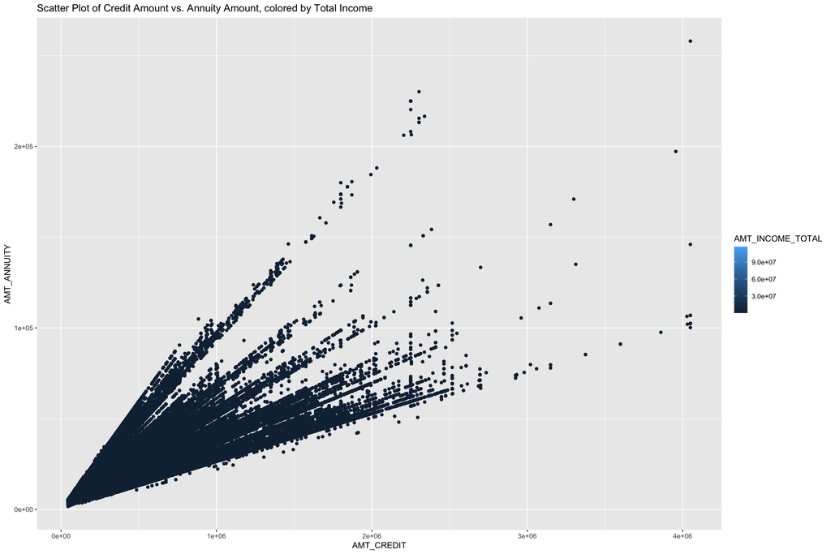

```r
## Histogram of Income
ggplot(TrainApplication, aes(x = AMT_CREDIT, y = AMT_ANNUITY, colour = AMT_INCOME_TOTAL)) + geom_point()+ggtitle("Scatter Plot of Credit Amount vs. Annuity Amount, colored by Total Income")
```

```r
# Get unique values in the column code_gender
unique_NAME_CONTRACT_TYPE <- unique(TrainApplication$NAME_CONTRACT_TYPE)

# Print the unique values
print(unique_NAME_CONTRACT_TYPE)
```

```
## [1] "Cash loans"      "Revolving loans"
```

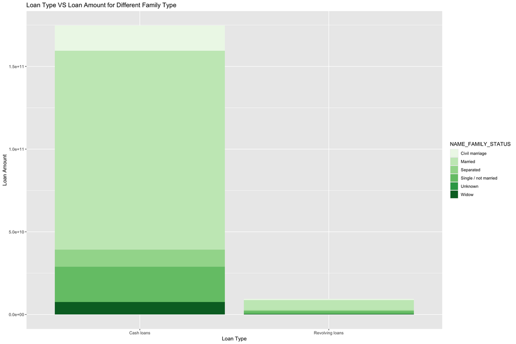

```r
 ggplot(data=TrainApplication, aes(x=NAME_CONTRACT_TYPE, y=(AMT_CREDIT),group=NAME_FAMILY_STATUS,
                           fill=NAME_FAMILY_STATUS))+
  geom_bar(stat="identity")+
  scale_fill_brewer(palette = "Set6") +
  xlab("Loan Type")+
  ylab("Loan Amount")+
  ggtitle("Loan Type VS Loan Amount for Different Family Type")
```

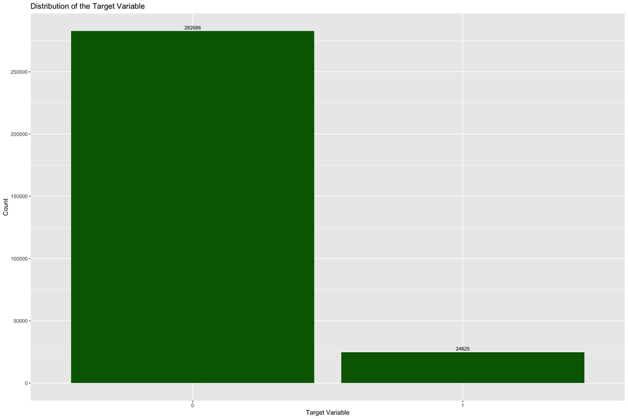

```r
ggplot(TrainApplication, aes(x = as.factor(TARGET))) +
  geom_bar(fill = "dark green") +
  geom_text(stat = "count", aes(label = ..count..), vjust = -0.5, color = "black", size = 3) +
  labs(x = "Target Variable", y = "Count") +
  ggtitle("Distribution of the Target Variable") +
  scale_y_continuous(breaks = seq(0, max(table(TrainApplication$TARGET)), by = 50000))
```

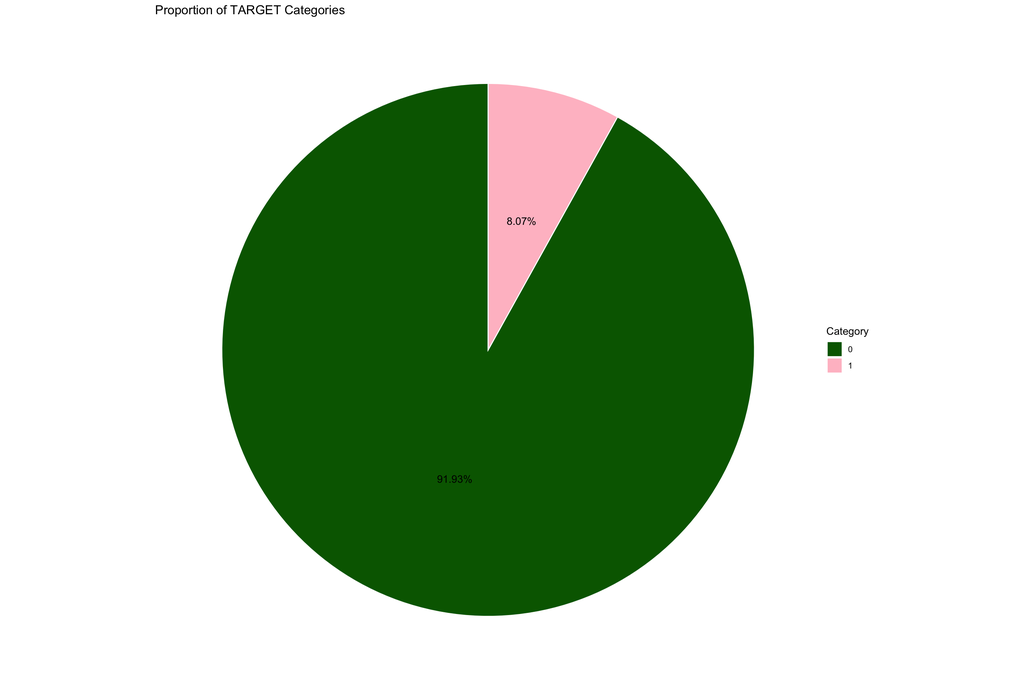

```r
# Calculate the proportion and convert it to percentages
proportion <- prop.table(table(TrainApplication$TARGET)) * 100

# Create a data frame for plotting
pie_data <- data.frame(category = names(proportion), proportion = proportion)

# Create the pie chart using ggplot
pie_chart <- ggplot(pie_data, aes(x = "", y = proportion, fill = category)) +
  geom_bar(stat = "identity", width = 1, color = "white") +
  coord_polar("y", start = 0) +
  theme_void() +
  labs(fill = "Category") +
  geom_text(aes(label = paste0(round(proportion, 2), "%")), position = position_stack(vjust = 0.5)) +
  labs(title = "Proportion of TARGET Categories") +
  scale_fill_manual(values = c("darkgreen", "pink"))

# Display the pie chart
print(pie_chart)
```

## Social Circle Data

Examining the remaining columns with missing values, four of them pertain to the applicant’s social circle and the 30-day and 60-day past due default status. It’s worth noting that there is only minimal missing data, with a total of 1021 instances.

```r
#install required packages
install.packages("gridExtra")
library(gridExtra)
library(grid)
# Dataframe with social variables
social_data_df <- TrainApplication %>% select(OBS_30_CNT_SOCIAL_CIRCLE,DEF_30_CNT_SOCIAL_CIRCLE,OBS_60_CNT_SOCIAL_CIRCLE,
                                  DEF_60_CNT_SOCIAL_CIRCLE)
summary(social_data_df)
```

```
##  OBS_30_CNT_SOCIAL_CIRCLE DEF_30_CNT_SOCIAL_CIRCLE OBS_60_CNT_SOCIAL_CIRCLE
##  Min.   :  0.000          Min.   : 0.0000          Min.   :  0.000
##  1st Qu.:  0.000          1st Qu.: 0.0000          1st Qu.:  0.000
##  Median :  0.000          Median : 0.0000          Median :  0.000
##  Mean   :  1.422          Mean   : 0.1434          Mean   :  1.405
##  3rd Qu.:  2.000          3rd Qu.: 0.0000          3rd Qu.:  2.000
##  Max.   :348.000          Max.   :34.0000          Max.   :344.000
##  NA's   :1021             NA's   :1021             NA's   :1021
##  DEF_60_CNT_SOCIAL_CIRCLE
##  Min.   : 0.0
##  1st Qu.: 0.0
##  Median : 0.0
##  Mean   : 0.1
##  3rd Qu.: 0.0
##  Max.   :24.0
##  NA's   :1021
```

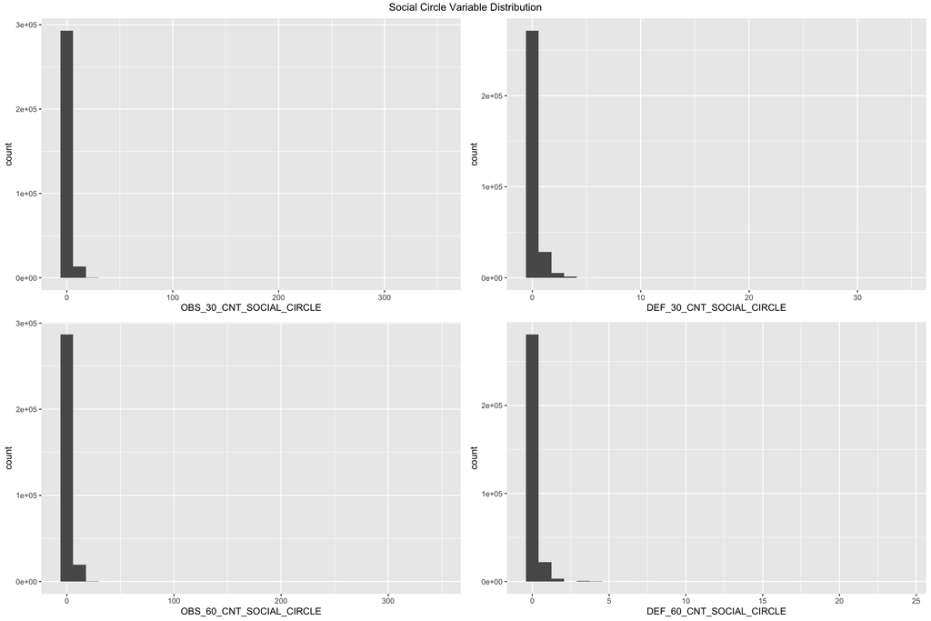

```r
# Create Plots
plot_OBS_30 <- ggplot(social_data_df, aes(OBS_30_CNT_SOCIAL_CIRCLE)) +
  geom_histogram()
plot_DEF_30 <- ggplot(social_data_df, aes(DEF_30_CNT_SOCIAL_CIRCLE)) +
  geom_histogram()
plot_OBS_60 <- ggplot(social_data_df, aes(OBS_60_CNT_SOCIAL_CIRCLE)) +
  geom_histogram()
plot_DEF_60 <- ggplot(social_data_df, aes(DEF_60_CNT_SOCIAL_CIRCLE)) +
  geom_histogram()

grid.arrange(plot_OBS_30,plot_DEF_30,plot_OBS_60,plot_DEF_60, ncol=2, top=textGrob('Social Circle Variable Distribution'))
```

# 5 Basic inspection of application train data

## 5.1 Scope of missing values

### 5.1.1 Rowwise completeness

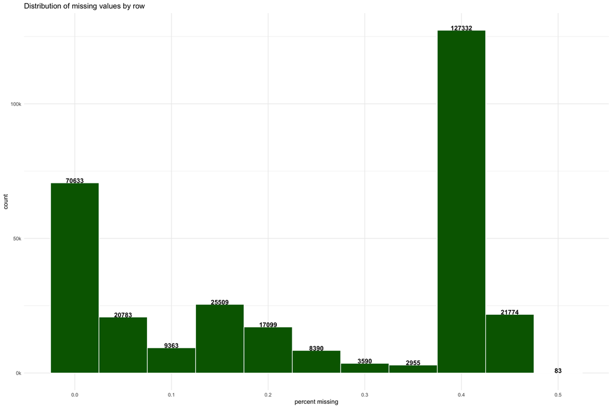

```r
TrainApplication %>%
  mutate(n_missing = rowSums(is.na(.)),
         p_missing = n_missing/ncol(.)) %>%
  ggplot() +
  geom_histogram(aes(p_missing),
                 binwidth = 0.05, fill = "darkgreen", color = "white") +
  stat_bin(aes(p_missing, y = after_stat(count), label = ifelse(after_stat(count) == 0, "", after_stat(count))),
           geom = "text", binwidth = 0.05, size = 4, fontface = "bold", vjust = 0) +
  scale_x_continuous(breaks = seq(0,1,0.1), minor_breaks = NULL) +
  scale_y_continuous(labels = ~paste0(.%/%1000, "k")) +
  labs(title = "Distribution of missing values by row",
       x = "percent missing") +
  theme_minimal()
```

# 6 Results

> Missing values are observed across various columns, necessitating careful consideration for imputation or removal.

> In summary, these insights shed light on the dataset’s characteristics, encompassing the target variable, missing data, and data quality. Despite the identified challenges, the dataset offers substantial records. Even with necessary data preprocessing steps, such as removal or imputation of columns and rows, there remains ample information to justify proceeding with the dataset into the modeling phase.